# Uniform vs Hierarchical Study design

## 1A. Linear model, single species

HMSC (Vignette 1) simulate univariate data, which represents population size `n` of a single species sampled at $i$ = 50 sampling units, each of which has a distinct value for an environmental covariate $x_i$. The data is simulated by the standard linear model with normally distributed residuals:

$$\begin{align}
y_i = \alpha + \beta x_i + \epsilon_i
\end{align}$$

where $\epsilon_i \sim N(0,\sigma^2)$

This can be alternatively written as:

$$\begin{align}
y_i = \sum^{n_c}_{k=1} x_{ik} \beta_k + \epsilon_i
\end{align}$$

Where the number of covariates is $n_c -1$, $\beta_1$ is the intercept term ($\alpha$) and $x_{i1} = 1$. We can also write this equation as:

$$\begin{align}
y_i \sim N(L_i,\sigma^2)
\end{align}$$

Where $L_i$ is called the linear predictor:

$$\begin{align}
L_i = \sum^{n_c}_{k=1} x_{ik}\beta_k
\end{align}$$

And `n` is the number of data points, `x` is a continuous covariate, `alpha` and `beta` are the true parameters for intercept and slope, `L` is the linear predictor, and `y` is the response variable (population size).

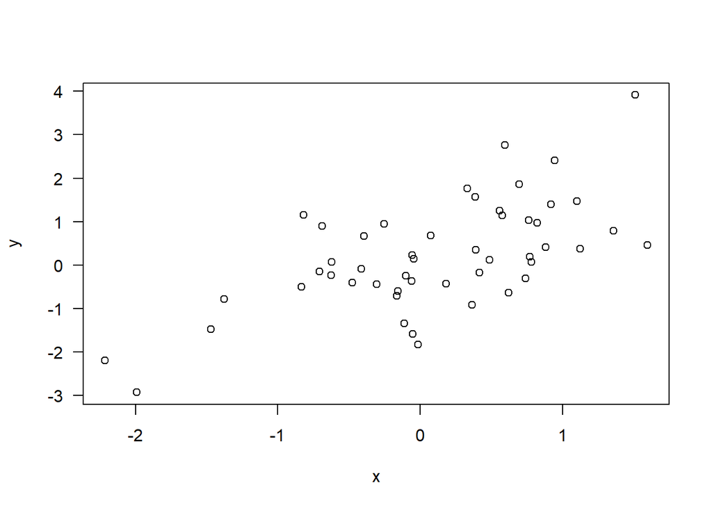

```r
set.seed(1)
n = 50
x = rnorm(n)
alpha = 0
beta = 1
sigma = 1
L = alpha + beta*x
y = L + rnorm(n, sd = sigma)
plot(x, y, las=1)
```

This data is analyzed via HMSC as follows:

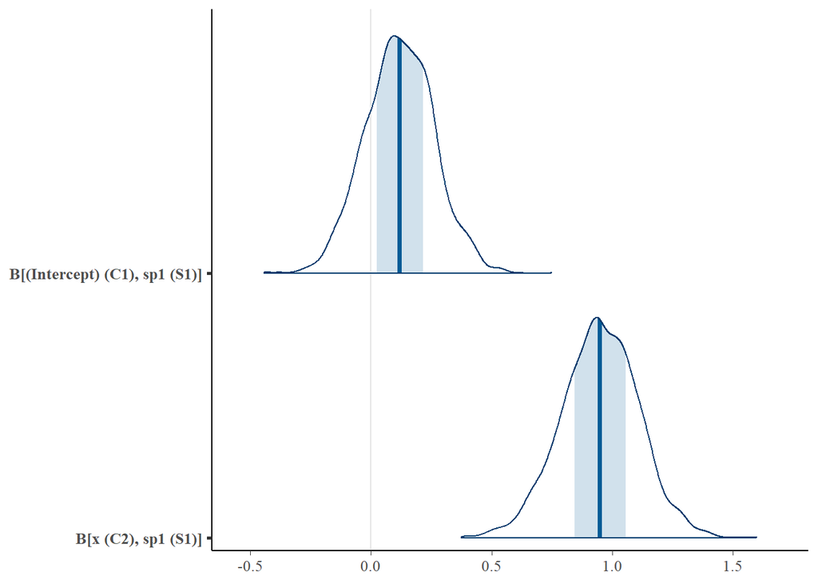

```r
Y = as.matrix(y)
XData = data.frame(x = x)
m = Hmsc(Y = Y, XData = XData, XFormula = ~x)
# MCMC parameters
nChains = 2
thin = 5
samples = 1000
transient = 500*thin
verbose = 500*thin

m = sampleMcmc(m, thin = thin, samples = samples, transient = transient, nChains = 2, verbose = verbose)

# Interpret results
m.post = Hmsc::convertToCodaObject(m)
m.df <- as.data.frame(rbind(m.post$Beta[[1]],m.post$Beta[[2]]))
bayesplot::mcmc_areas(m.df)
```

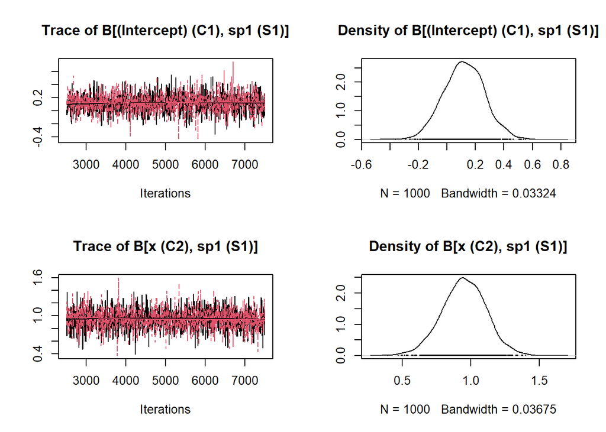

```r
summary(m.post$Beta)
plot(m.post$Beta)
```

[output not shown]

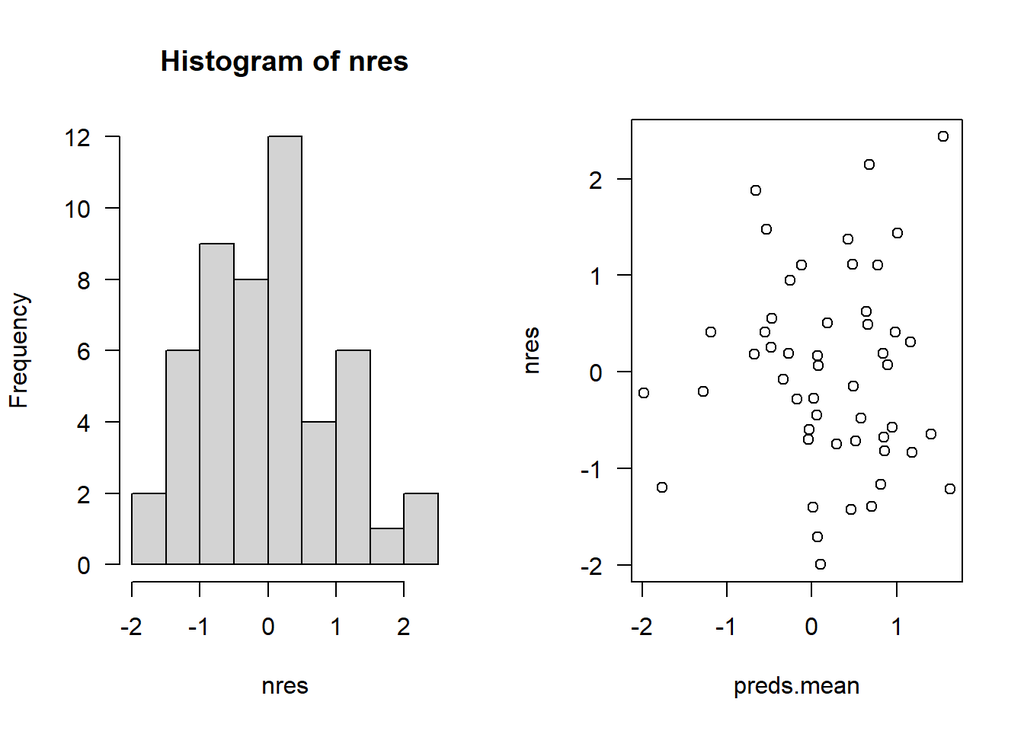

```r
preds = computePredictedValues(m)
evaluateModelFit(hM=m, predY=preds)
preds.mean = apply(preds, FUN=mean, MARGIN=1)
nres = scale(y-preds.mean)
par(mfrow=c(1,2))
hist(nres, las = 1)
plot(preds.mean,nres, las = 1)
```

[output not shown]

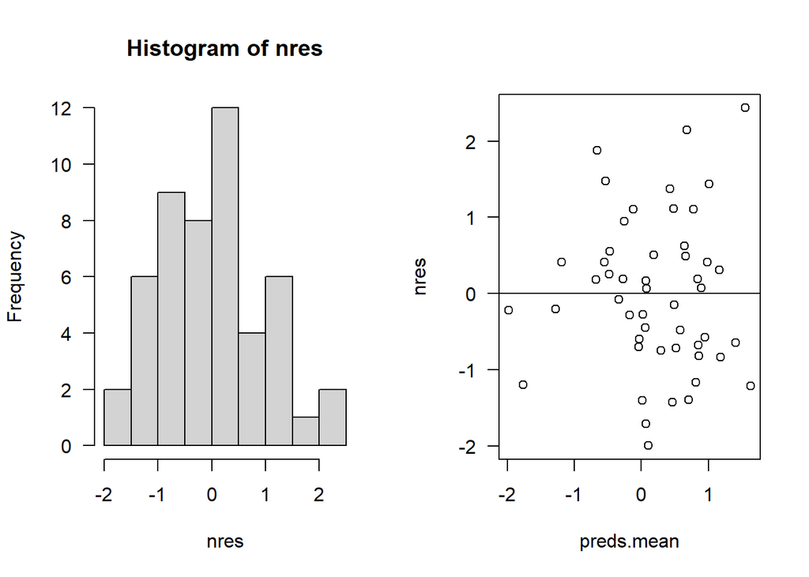

```r
abline(a=0,b=0)
```

## 1B. Linear mixed model, single species, spatial (heirarcahical) study design

We now consider a population growing, where the species abundance is sampled from sites that are nested within plots. In such a case, two observations from the same plot are likely to be more similar to each other than two observations indifferent plots. We now introduce residuals for observations $y_i$ that are not independent of one another, and introduce into the statistical model a plot-level random effect.

As indicated in Ovaskainen & Abrego (Chapter 5), a standard way of implementing this dependency structure into the model is to add a plot-level random effect. To do so we use $a_p$ to denote the effect of plot $p$. The random effects are assumed to be normally distributed, so that
$$a_p \sim
N(0,\sigma^2_p)$$
, where
$$\sigma^2_p$$
is the variance in the plot-level effects. Right now, this suggests that in addition to the residual variance $\epsilon_i$, each data point also has residual variance associated with the sampling plot $a_p$. We can now extend the basic linear model into a mixed model:

$$y_i = L_i + a_{p(i)} + \epsilon_i$$
$$a_{p(i)} \sim N(0,\sigma^2_p)$$
$$\epsilon_i \sim N(0,\sigma^2)$$
This is called a *mixed model* because it includes both fixed effects, i.e. the regression parameters included in the linear predictor $L_i$, as well as random effects, i.e. the effect of sampling date.

JDSM Chapter 5 text tells us another way of writing this equation (5.7 in the text), using the *multivariate normal distribution* for describing the distribution of response variables $y_i$ for all sampling units *i* - we denote by $\mathbf{y}$ the vector of length *n* (number of sampling units) with all of the values of $y_i$, we denote by $\mathbf{L}$ the vector of all linear predictors $L_i$, and by $\mathbf{\epsilon}$ the vector of all residuals $\epsilon_i$. We can then rewrite the equation as:

$$\mathbf{y} \sim \mathbf{L} +
\epsilon_i$$
$$\epsilon_i \sim
N(\mathbf{0},\mathbf{\Sigma})$$

Where $N(\mathbf{\mu},\mathbf{\Sigma})$ stands for the multivariate normal distribution with mean $\mathbf{\mu}$ and variance-covariance matrix $\mathbf{\Sigma}$. We can also write out what this looks like for this example so far:

$$\begin{bmatrix} y_1\\
y_2\\
y_{...}\\
y_i
\end{bmatrix} = \begin{bmatrix}\beta_1 x_1\\
\beta_2 x_2\\
\end{bmatrix} \begin{bmatrix}\epsilon_1\\
\epsilon_2\\
\epsilon_{...}\\
\epsilon_i
\end{bmatrix}$$

In this equation above, the vector $\mathbf{\mu}$ is set to 0 because the expectation of each $\epsilon_i$ value is 0.

The diagonal elements of the variance-covariance matrix $\mathbf{\Sigma}$ model the variances, and thus are set to $\Sigma_{ii} = \sigma^2_p + \sigma^2$. The off-diagonal elements of the variance-covariance matrix $\mathbf{\Sigma}$ model the covariances, and here are set to $\Sigma_{ij} = \sigma^2_p$ if the sampling units *i* and *j* belong to the same plot, and $\Sigma_{ij} = 0$ if the sampling units *i* and *j* belong to different plots.

```r
samp <- rep(1:5,each=10)
sig <- 4
ap <- 0.8
m<-matrix(rep(NA,2500),ncol=50)
for(i in 1:50){
    for(j in 1:50){
       if(samp[i]==samp[j]){
           m[i,j] <- sig
           }
       else{
           m[i,j] <- 0
       }
    }
}
m <- as.matrix(m)
diag(m) <- ap + sig
```

For the example above, this variance-covariance matrix looks like this:

| 4.8 | 4.0 | 4.0 | 4.0 | 4.0 | 4.0 | 4.0 | 4.0 | 4.0 | 4.0 | 0.0 | 0.0 | 0.0 | 0.0 | 0.0 | 0.0 | 0.0 | 0.0 | 0.0 | 0.0 | 0.0 | 0.0 | 0.0 | 0.0 | 0.0 | 0.0 | 0.0 | 0.0 | 0.0 | 0.0 | … |
| --- | --- | --- | --- | --- | --- | --- | --- | --- | --- | --- | --- | --- | --- | --- | --- | --- | --- | --- | --- | --- | --- | --- | --- | --- | --- | --- | --- | --- | --- | --- |
| 4.0 | 4.8 | 4.0 | 4.0 | 4.0 | 4.0 | 4.0 | 4.0 | 4.0 | 4.0 | 0.0 | 0.0 | 0.0 | 0.0 | 0.0 | 0.0 | 0.0 | 0.0 | 0.0 | 0.0 | 0.0 | 0.0 | 0.0 | 0.0 | 0.0 | 0.0 | 0.0 | 0.0 | 0.0 | 0.0 | … |
| 4.0 | 4.0 | 4.8 | 4.0 | 4.0 | 4.0 | 4.0 | 4.0 | 4.0 | 4.0 | 0.0 | 0.0 | 0.0 | 0.0 | 0.0 | 0.0 | 0.0 | 0.0 | 0.0 | 0.0 | 0.0 | 0.0 | 0.0 | 0.0 | 0.0 | 0.0 | 0.0 | 0.0 | 0.0 | 0.0 | … |
| 4.0 | 4.0 | 4.0 | 4.8 | 4.0 | 4.0 | 4.0 | 4.0 | 4.0 | 4.0 | 0.0 | 0.0 | 0.0 | 0.0 | 0.0 | 0.0 | 0.0 | 0.0 | 0.0 | 0.0 | 0.0 | 0.0 | 0.0 | 0.0 | 0.0 | 0.0 | 0.0 | 0.0 | 0.0 | 0.0 | … |
| 4.0 | 4.0 | 4.0 | 4.0 | 4.8 | 4.0 | 4.0 | 4.0 | 4.0 | 4.0 | 0.0 | 0.0 | 0.0 | 0.0 | 0.0 | 0.0 | 0.0 | 0.0 | 0.0 | 0.0 | 0.0 | 0.0 | 0.0 | 0.0 | 0.0 | 0.0 | 0.0 | 0.0 | 0.0 | 0.0 | … |
| 4.0 | 4.0 | 4.0 | 4.0 | 4.0 | 4.8 | 4.0 | 4.0 | 4.0 | 4.0 | 0.0 | 0.0 | 0.0 | 0.0 | 0.0 | 0.0 | 0.0 | 0.0 | 0.0 | 0.0 | 0.0 | 0.0 | 0.0 | 0.0 | 0.0 | 0.0 | 0.0 | 0.0 | 0.0 | 0.0 | … |
| 4.0 | 4.0 | 4.0 | 4.0 | 4.0 | 4.0 | 4.8 | 4.0 | 4.0 | 4.0 | 0.0 | 0.0 | 0.0 | 0.0 | 0.0 | 0.0 | 0.0 | 0.0 | 0.0 | 0.0 | 0.0 | 0.0 | 0.0 | 0.0 | 0.0 | 0.0 | 0.0 | 0.0 | 0.0 | 0.0 | … |
| 4.0 | 4.0 | 4.0 | 4.0 | 4.0 | 4.0 | 4.0 | 4.8 | 4.0 | 4.0 | 0.0 | 0.0 | 0.0 | 0.0 | 0.0 | 0.0 | 0.0 | 0.0 | 0.0 | 0.0 | 0.0 | 0.0 | 0.0 | 0.0 | 0.0 | 0.0 | 0.0 | 0.0 | 0.0 | 0.0 | … |
| 4.0 | 4.0 | 4.0 | 4.0 | 4.0 | 4.0 | 4.0 | 4.0 | 4.8 | 4.0 | 0.0 | 0.0 | 0.0 | 0.0 | 0.0 | 0.0 | 0.0 | 0.0 | 0.0 | 0.0 | 0.0 | 0.0 | 0.0 | 0.0 | 0.0 | 0.0 | 0.0 | 0.0 | 0.0 | 0.0 | … |
| 4.0 | 4.0 | 4.0 | 4.0 | 4.0 | 4.0 | 4.0 | 4.0 | 4.0 | 4.8 | 0.0 | 0.0 | 0.0 | 0.0 | 0.0 | 0.0 | 0.0 | 0.0 | 0.0 | 0.0 | 0.0 | 0.0 | 0.0 | 0.0 | 0.0 | 0.0 | 0.0 | 0.0 | 0.0 | 0.0 | … |
| 0.0 | 0.0 | 0.0 | 0.0 | 0.0 | 0.0 | 0.0 | 0.0 | 0.0 | 0.0 | 4.8 | 4.0 | 4.0 | 4.0 | 4.0 | 4.0 | 4.0 | 4.0 | 4.0 | 4.0 | 0.0 | 0.0 | 0.0 | 0.0 | 0.0 | 0.0 | 0.0 | 0.0 | 0.0 | 0.0 | … |
| 0.0 | 0.0 | 0.0 | 0.0 | 0.0 | 0.0 | 0.0 | 0.0 | 0.0 | 0.0 | 4.0 | 4.8 | 4.0 | 4.0 | 4.0 | 4.0 | 4.0 | 4.0 | 4.0 | 4.0 | 0.0 | 0.0 | 0.0 | 0.0 | 0.0 | 0.0 | 0.0 | 0.0 | 0.0 | 0.0 | … |
| 0.0 | 0.0 | 0.0 | 0.0 | 0.0 | 0.0 | 0.0 | 0.0 | 0.0 | 0.0 | 4.0 | 4.0 | 4.8 | 4.0 | 4.0 | 4.0 | 4.0 | 4.0 | 4.0 | 4.0 | 0.0 | 0.0 | 0.0 | 0.0 | 0.0 | 0.0 | 0.0 | 0.0 | 0.0 | 0.0 | … |
| 0.0 | 0.0 | 0.0 | 0.0 | 0.0 | 0.0 | 0.0 | 0.0 | 0.0 | 0.0 | 4.0 | 4.0 | 4.0 | 4.8 | 4.0 | 4.0 | 4.0 | 4.0 | 4.0 | 4.0 | 0.0 | 0.0 | 0.0 | 0.0 | 0.0 | 0.0 | 0.0 | 0.0 | 0.0 | 0.0 | … |
| 0.0 | 0.0 | 0.0 | 0.0 | 0.0 | 0.0 | 0.0 | 0.0 | 0.0 | 0.0 | 4.0 | 4.0 | 4.0 | 4.0 | 4.8 | 4.0 | 4.0 | 4.0 | 4.0 | 4.0 | 0.0 | 0.0 | 0.0 | 0.0 | 0.0 | 0.0 | 0.0 | 0.0 | 0.0 | 0.0 | … |
| 0.0 | 0.0 | 0.0 | 0.0 | 0.0 | 0.0 | 0.0 | 0.0 | 0.0 | 0.0 | 4.0 | 4.0 | 4.0 | 4.0 | 4.0 | 4.8 | 4.0 | 4.0 | 4.0 | 4.0 | 0.0 | 0.0 | 0.0 | 0.0 | 0.0 | 0.0 | 0.0 | 0.0 | 0.0 | 0.0 | … |
| 0.0 | 0.0 | 0.0 | 0.0 | 0.0 | 0.0 | 0.0 | 0.0 | 0.0 | 0.0 | 4.0 | 4.0 | 4.0 | 4.0 | 4.0 | 4.0 | 4.8 | 4.0 | 4.0 | 4.0 | 0.0 | 0.0 | 0.0 | 0.0 | 0.0 | 0.0 | 0.0 | 0.0 | 0.0 | 0.0 | … |
| 0.0 | 0.0 | 0.0 | 0.0 | 0.0 | 0.0 | 0.0 | 0.0 | 0.0 | 0.0 | 4.0 | 4.0 | 4.0 | 4.0 | 4.0 | 4.0 | 4.0 | 4.8 | 4.0 | 4.0 | 0.0 | 0.0 | 0.0 | 0.0 | 0.0 | 0.0 | 0.0 | 0.0 | 0.0 | 0.0 | … |
| 0.0 | 0.0 | 0.0 | 0.0 | 0.0 | 0.0 | 0.0 | 0.0 | 0.0 | 0.0 | 4.0 | 4.0 | 4.0 | 4.0 | 4.0 | 4.0 | 4.0 | 4.0 | 4.8 | 4.0 | 0.0 | 0.0 | 0.0 | 0.0 | 0.0 | 0.0 | 0.0 | 0.0 | 0.0 | 0.0 | … |
| 0.0 | 0.0 | 0.0 | 0.0 | 0.0 | 0.0 | 0.0 | 0.0 | 0.0 | 0.0 | 4.0 | 4.0 | 4.0 | 4.0 | 4.0 | 4.0 | 4.0 | 4.0 | 4.0 | 4.8 | 0.0 | 0.0 | 0.0 | 0.0 | 0.0 | 0.0 | 0.0 | 0.0 | 0.0 | 0.0 | … |
| 0.0 | 0.0 | 0.0 | 0.0 | 0.0 | 0.0 | 0.0 | 0.0 | 0.0 | 0.0 | 0.0 | 0.0 | 0.0 | 0.0 | 0.0 | 0.0 | 0.0 | 0.0 | 0.0 | 0.0 | 4.8 | 4.0 | 4.0 | 4.0 | 4.0 | 4.0 | 4.0 | 4.0 | 4.0 | 4.0 | … |
| 0.0 | 0.0 | 0.0 | 0.0 | 0.0 | 0.0 | 0.0 | 0.0 | 0.0 | 0.0 | 0.0 | 0.0 | 0.0 | 0.0 | 0.0 | 0.0 | 0.0 | 0.0 | 0.0 | 0.0 | 4.0 | 4.8 | 4.0 | 4.0 | 4.0 | 4.0 | 4.0 | 4.0 | 4.0 | 4.0 | … |
| 0.0 | 0.0 | 0.0 | 0.0 | 0.0 | 0.0 | 0.0 | 0.0 | 0.0 | 0.0 | 0.0 | 0.0 | 0.0 | 0.0 | 0.0 | 0.0 | 0.0 | 0.0 | 0.0 | 0.0 | 4.0 | 4.0 | 4.8 | 4.0 | 4.0 | 4.0 | 4.0 | 4.0 | 4.0 | 4.0 | … |
| 0.0 | 0.0 | 0.0 | 0.0 | 0.0 | 0.0 | 0.0 | 0.0 | 0.0 | 0.0 | 0.0 | 0.0 | 0.0 | 0.0 | 0.0 | 0.0 | 0.0 | 0.0 | 0.0 | 0.0 | 4.0 | 4.0 | 4.0 | 4.8 | 4.0 | 4.0 | 4.0 | 4.0 | 4.0 | 4.0 | … |
| 0.0 | 0.0 | 0.0 | 0.0 | 0.0 | 0.0 | 0.0 | 0.0 | 0.0 | 0.0 | 0.0 | 0.0 | 0.0 | 0.0 | 0.0 | 0.0 | 0.0 | 0.0 | 0.0 | 0.0 | 4.0 | 4.0 | 4.0 | 4.0 | 4.8 | 4.0 | 4.0 | 4.0 | 4.0 | 4.0 | … |
| 0.0 | 0.0 | 0.0 | 0.0 | 0.0 | 0.0 | 0.0 | 0.0 | 0.0 | 0.0 | 0.0 | 0.0 | 0.0 | 0.0 | 0.0 | 0.0 | 0.0 | 0.0 | 0.0 | 0.0 | 4.0 | 4.0 | 4.0 | 4.0 | 4.0 | 4.8 | 4.0 | 4.0 | 4.0 | 4.0 | … |
| 0.0 | 0.0 | 0.0 | 0.0 | 0.0 | 0.0 | 0.0 | 0.0 | 0.0 | 0.0 | 0.0 | 0.0 | 0.0 | 0.0 | 0.0 | 0.0 | 0.0 | 0.0 | 0.0 | 0.0 | 4.0 | 4.0 | 4.0 | 4.0 | 4.0 | 4.0 | 4.8 | 4.0 | 4.0 | 4.0 | … |
| 0.0 | 0.0 | 0.0 | 0.0 | 0.0 | 0.0 | 0.0 | 0.0 | 0.0 | 0.0 | 0.0 | 0.0 | 0.0 | 0.0 | 0.0 | 0.0 | 0.0 | 0.0 | 0.0 | 0.0 | 4.0 | 4.0 | 4.0 | 4.0 | 4.0 | 4.0 | 4.0 | 4.8 | 4.0 | 4.0 | … |
| 0.0 | 0.0 | 0.0 | 0.0 | 0.0 | 0.0 | 0.0 | 0.0 | 0.0 | 0.0 | 0.0 | 0.0 | 0.0 | 0.0 | 0.0 | 0.0 | 0.0 | 0.0 | 0.0 | 0.0 | 4.0 | 4.0 | 4.0 | 4.0 | 4.0 | 4.0 | 4.0 | 4.0 | 4.8 | 4.0 | … |
| 0.0 | 0.0 | 0.0 | 0.0 | 0.0 | 0.0 | 0.0 | 0.0 | 0.0 | 0.0 | 0.0 | 0.0 | 0.0 | 0.0 | 0.0 | 0.0 | 0.0 | 0.0 | 0.0 | 0.0 | 4.0 | 4.0 | 4.0 | 4.0 | 4.0 | 4.0 | 4.0 | 4.0 | 4.0 | 4.8 | … |
| 0.0 | 0.0 | 0.0 | 0.0 | 0.0 | 0.0 | 0.0 | 0.0 | 0.0 | 0.0 | 0.0 | 0.0 | 0.0 | 0.0 | 0.0 | 0.0 | 0.0 | 0.0 | 0.0 | 0.0 | 0.0 | 0.0 | 0.0 | 0.0 | 0.0 | 0.0 | 0.0 | 0.0 | 0.0 | 0.0 | … |
| 0.0 | 0.0 | 0.0 | 0.0 | 0.0 | 0.0 | 0.0 | 0.0 | 0.0 | 0.0 | 0.0 | 0.0 | 0.0 | 0.0 | 0.0 | 0.0 | 0.0 | 0.0 | 0.0 | 0.0 | 0.0 | 0.0 | 0.0 | 0.0 | 0.0 | 0.0 | 0.0 | 0.0 | 0.0 | 0.0 | … |
| 0.0 | 0.0 | 0.0 | 0.0 | 0.0 | 0.0 | 0.0 | 0.0 | 0.0 | 0.0 | 0.0 | 0.0 | 0.0 | 0.0 | 0.0 | 0.0 | 0.0 | 0.0 | 0.0 | 0.0 | 0.0 | 0.0 | 0.0 | 0.0 | 0.0 | 0.0 | 0.0 | 0.0 | 0.0 | 0.0 | … |
| 0.0 | 0.0 | 0.0 | 0.0 | 0.0 | 0.0 | 0.0 | 0.0 | 0.0 | 0.0 | 0.0 | 0.0 | 0.0 | 0.0 | 0.0 | 0.0 | 0.0 | 0.0 | 0.0 | 0.0 | 0.0 | 0.0 | 0.0 | 0.0 | 0.0 | 0.0 | 0.0 | 0.0 | 0.0 | 0.0 | … |
| 0.0 | 0.0 | 0.0 | 0.0 | 0.0 | 0.0 | 0.0 | 0.0 | 0.0 | 0.0 | 0.0 | 0.0 | 0.0 | 0.0 | 0.0 | 0.0 | 0.0 | 0.0 | 0.0 | 0.0 | 0.0 | 0.0 | 0.0 | 0.0 | 0.0 | 0.0 | 0.0 | 0.0 | 0.0 | 0.0 | … |
| 0.0 | 0.0 | 0.0 | 0.0 | 0.0 | 0.0 | 0.0 | 0.0 | 0.0 | 0.0 | 0.0 | 0.0 | 0.0 | 0.0 | 0.0 | 0.0 | 0.0 | 0.0 | 0.0 | 0.0 | 0.0 | 0.0 | 0.0 | 0.0 | 0.0 | 0.0 | 0.0 | 0.0 | 0.0 | 0.0 | … |
| 0.0 | 0.0 | 0.0 | 0.0 | 0.0 | 0.0 | 0.0 | 0.0 | 0.0 | 0.0 | 0.0 | 0.0 | 0.0 | 0.0 | 0.0 | 0.0 | 0.0 | 0.0 | 0.0 | 0.0 | 0.0 | 0.0 | 0.0 | 0.0 | 0.0 | 0.0 | 0.0 | 0.0 | 0.0 | 0.0 | … |
| 0.0 | 0.0 | 0.0 | 0.0 | 0.0 | 0.0 | 0.0 | 0.0 | 0.0 | 0.0 | 0.0 | 0.0 | 0.0 | 0.0 | 0.0 | 0.0 | 0.0 | 0.0 | 0.0 | 0.0 | 0.0 | 0.0 | 0.0 | 0.0 | 0.0 | 0.0 | 0.0 | 0.0 | 0.0 | 0.0 | … |
| 0.0 | 0.0 | 0.0 | 0.0 | 0.0 | 0.0 | 0.0 | 0.0 | 0.0 | 0.0 | 0.0 | 0.0 | 0.0 | 0.0 | 0.0 | 0.0 | 0.0 | 0.0 | 0.0 | 0.0 | 0.0 | 0.0 | 0.0 | 0.0 | 0.0 | 0.0 | 0.0 | 0.0 | 0.0 | 0.0 | … |
| 0.0 | 0.0 | 0.0 | 0.0 | 0.0 | 0.0 | 0.0 | 0.0 | 0.0 | 0.0 | 0.0 | 0.0 | 0.0 | 0.0 | 0.0 | 0.0 | 0.0 | 0.0 | 0.0 | 0.0 | 0.0 | 0.0 | 0.0 | 0.0 | 0.0 | 0.0 | 0.0 | 0.0 | 0.0 | 0.0 | … |
| 0.0 | 0.0 | 0.0 | 0.0 | 0.0 | 0.0 | 0.0 | 0.0 | 0.0 | 0.0 | 0.0 | 0.0 | 0.0 | 0.0 | 0.0 | 0.0 | 0.0 | 0.0 | 0.0 | 0.0 | 0.0 | 0.0 | 0.0 | 0.0 | 0.0 | 0.0 | 0.0 | 0.0 | 0.0 | 0.0 | … |
| 0.0 | 0.0 | 0.0 | 0.0 | 0.0 | 0.0 | 0.0 | 0.0 | 0.0 | 0.0 | 0.0 | 0.0 | 0.0 | 0.0 | 0.0 | 0.0 | 0.0 | 0.0 | 0.0 | 0.0 | 0.0 | 0.0 | 0.0 | 0.0 | 0.0 | 0.0 | 0.0 | 0.0 | 0.0 | 0.0 | … |
| 0.0 | 0.0 | 0.0 | 0.0 | 0.0 | 0.0 | 0.0 | 0.0 | 0.0 | 0.0 | 0.0 | 0.0 | 0.0 | 0.0 | 0.0 | 0.0 | 0.0 | 0.0 | 0.0 | 0.0 | 0.0 | 0.0 | 0.0 | 0.0 | 0.0 | 0.0 | 0.0 | 0.0 | 0.0 | 0.0 | … |
| 0.0 | 0.0 | 0.0 | 0.0 | 0.0 | 0.0 | 0.0 | 0.0 | 0.0 | 0.0 | 0.0 | 0.0 | 0.0 | 0.0 | 0.0 | 0.0 | 0.0 | 0.0 | 0.0 | 0.0 | 0.0 | 0.0 | 0.0 | 0.0 | 0.0 | 0.0 | 0.0 | 0.0 | 0.0 | 0.0 | … |
| 0.0 | 0.0 | 0.0 | 0.0 | 0.0 | 0.0 | 0.0 | 0.0 | 0.0 | 0.0 | 0.0 | 0.0 | 0.0 | 0.0 | 0.0 | 0.0 | 0.0 | 0.0 | 0.0 | 0.0 | 0.0 | 0.0 | 0.0 | 0.0 | 0.0 | 0.0 | 0.0 | 0.0 | 0.0 | 0.0 | … |
| 0.0 | 0.0 | 0.0 | 0.0 | 0.0 | 0.0 | 0.0 | 0.0 | 0.0 | 0.0 | 0.0 | 0.0 | 0.0 | 0.0 | 0.0 | 0.0 | 0.0 | 0.0 | 0.0 | 0.0 | 0.0 | 0.0 | 0.0 | 0.0 | 0.0 | 0.0 | 0.0 | 0.0 | 0.0 | 0.0 | … |
| 0.0 | 0.0 | 0.0 | 0.0 | 0.0 | 0.0 | 0.0 | 0.0 | 0.0 | 0.0 | 0.0 | 0.0 | 0.0 | 0.0 | 0.0 | 0.0 | 0.0 | 0.0 | 0.0 | 0.0 | 0.0 | 0.0 | 0.0 | 0.0 | 0.0 | 0.0 | 0.0 | 0.0 | 0.0 | 0.0 | … |
| 0.0 | 0.0 | 0.0 | 0.0 | 0.0 | 0.0 | 0.0 | 0.0 | 0.0 | 0.0 | 0.0 | 0.0 | 0.0 | 0.0 | 0.0 | 0.0 | 0.0 | 0.0 | 0.0 | 0.0 | 0.0 | 0.0 | 0.0 | 0.0 | 0.0 | 0.0 | 0.0 | 0.0 | 0.0 | 0.0 | … |
| 0.0 | 0.0 | 0.0 | 0.0 | 0.0 | 0.0 | 0.0 | 0.0 | 0.0 | 0.0 | 0.0 | 0.0 | 0.0 | 0.0 | 0.0 | 0.0 | 0.0 | 0.0 | 0.0 | 0.0 | 0.0 | 0.0 | 0.0 | 0.0 | 0.0 | 0.0 | 0.0 | 0.0 | 0.0 | 0.0 | … |
| 0.0 | 0.0 | 0.0 | 0.0 | 0.0 | 0.0 | 0.0 | 0.0 | 0.0 | 0.0 | 0.0 | 0.0 | 0.0 | 0.0 | 0.0 | 0.0 | 0.0 | 0.0 | 0.0 | 0.0 | 0.0 | 0.0 | 0.0 | 0.0 | 0.0 | 0.0 | 0.0 | 0.0 | 0.0 | 0.0 | … |

[figure not shown]

```r
# 2 heirarchical groups: mean [0 2], variance [10 2], covariance [3]. Draw for 10 points from each group.
Sigma <- matrix(c(10,3,3,2),2,2)
Sigma
```

```
##      [,1] [,2]
## [1,]   10    3
## [2,]    3    2
```

```r
blah <- MASS::mvrnorm(n = 100, c(0,2), Sigma)
var(blah)
```

```
##           [,1]     [,2]
## [1,] 10.616254 3.332077
## [2,]  3.332077 1.845607
```

Now we can draw the residuals $\epsilon_i$ for our hypothetical 50 sites sampled across 5 plots this way:

```r
# 5 heirarchical groups: mean [0 0 0 0 0 0 0 0 0 0]; variance: [4.8 4.8 4.8 4.8 4.8 4.8 4.8 4.8 4.8 4.8 4.8]; covariance: see matrix above. Draw for 1 point from each group.
resid <-  MASS::mvrnorm(1, rep(0,50), m)
```

Putting it all together - we now attempt to sample data points that represent population size `n` of a single species sampled at `i= 50` sampling units, each of which has a distinct value for an environmental covariate $x_i$. Each of the sampling units was sampled in one of 5 plots (as above), meaning that we need to consider not only variance but also covariance between sampling unit values sampled in the same plot. Our model becomes:

$$y_i = L_i + a_{p(i)} + \epsilon_i$$
$$L_i = \sum^{n_c}_{k=1} x_{ik}
\beta_k$$
$$a_{p(i)} \sim
N(0,\sigma^2_p)$$
$$\epsilon_i \sim
N(0,\sigma^2)$$

For this example:

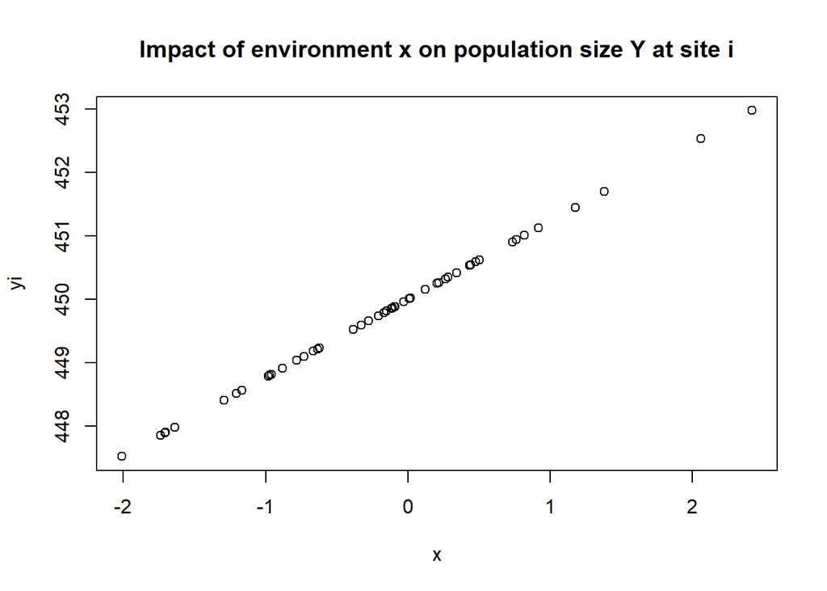

```r
n <- 50
x <- rnorm(n)
x1 <- rep(1,n)
x2 <- x
beta1 <- 450
beta2 <- 1.23
L <- beta1*x1 + beta2*x2

## Method 1 of drawing residual values
n.plot <- rep(1:5,each=10)
sigma.plot <- c(0.25,0.35,0.23,0.05,0.1)
ap <- rep(NA,n)
for(i in 1:n){
  ap[i] <- rnorm(1,0,sd = sigma.plot[n.plot[i]])
}
y <- L + ap + rnorm(n, sd=0.7)
plot(x,L,main="Impact of environment x on population size Y at site i",ylab="yi")
```

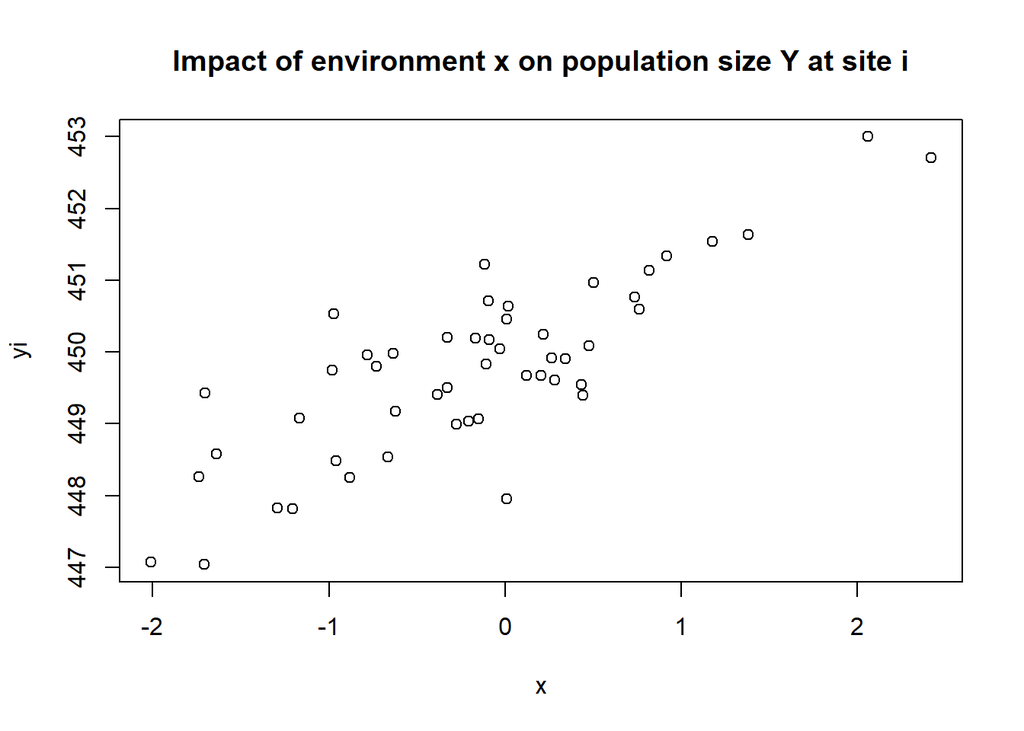

```r
plot(x,y,main="Impact of environment x on population size Y at site i",ylab="yi")
```

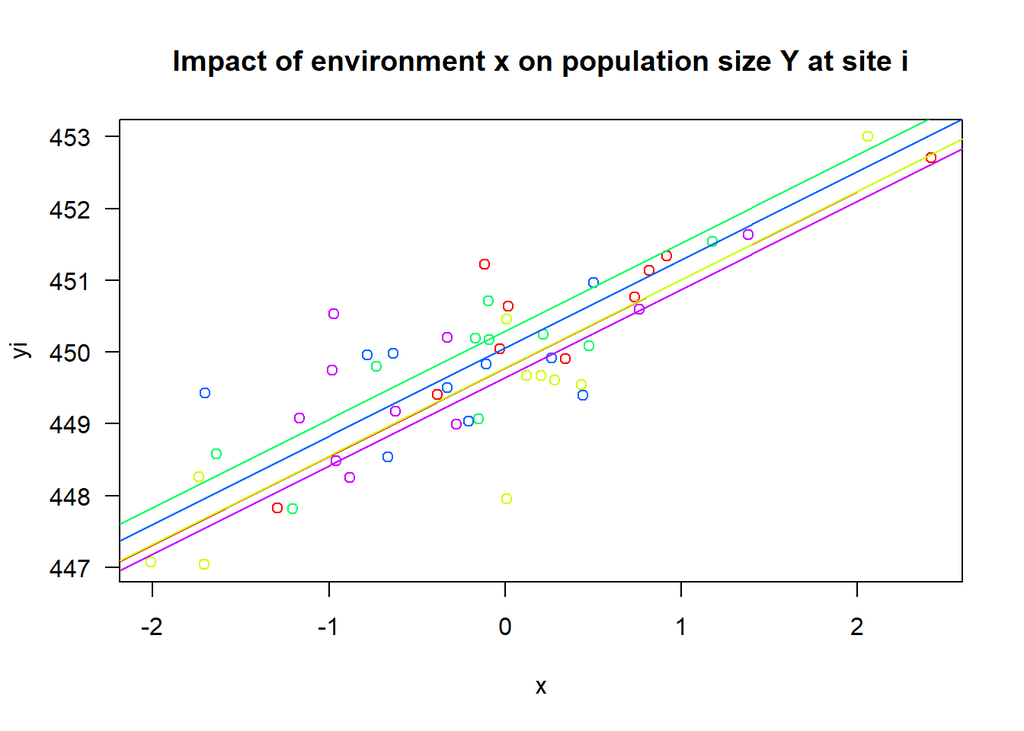

```r
# colored by day
cols = rainbow(5)
plot(x, y, col = cols[n.plot], las = 1, main="Impact of environment x on population size Y at site i",ylab="yi")
for (p in 1:5){
abline(beta1+ap[p], beta2, col = cols[p]) }
```

This data is analyzed via mixed models as follows:

```r
n.plot <- as.factor(n.plot)
# random intercepts only
mod <- lme4::lmer(y ~ x + (1 | n.plot))
# random intercepts and slopes
#mod <- lme4::lmer(y ~ x + (1 + x | n.plot))
summary(mod)
```

```
## Linear mixed model fit by REML ['lmerMod']
## Formula: y ~ x + (1 | n.plot)
##
## REML criterion at convergence: 112.5
##
## Scaled residuals:
##      Min       1Q   Median       3Q      Max
## -2.62409 -0.71237 -0.00504  0.60210  2.23831
##
## Random effects:
##  Groups   Name        Variance Std.Dev.
##  n.plot   (Intercept) 0.02288  0.1513
##  Residual             0.50405  0.7100
## Number of obs: 50, groups:  n.plot, 5
##
## Fixed effects:
##             Estimate Std. Error t value
## (Intercept) 449.9603     0.1225 3673.89
## x             1.0985     0.1104    9.95
##
## Correlation of Fixed Effects:
##   (Intr)
## x 0.151
```

```r
mixedup::extract_random_effects(mod)
```

```
## # A tibble: 5 × 7
##   group_var effect    group  value    se lower_2.5 upper_97.5
##   <chr>     <chr>     <fct>  <dbl> <dbl>     <dbl>      <dbl>
## 1 n.plot    Intercept 1      0.051 0.125    -0.195      0.297
## 2 n.plot    Intercept 2     -0.148 0.125    -0.394      0.098
## 3 n.plot    Intercept 3      0.033 0.125    -0.213      0.279
## 4 n.plot    Intercept 4      0.015 0.125    -0.231      0.261
## 5 n.plot    Intercept 5      0.049 0.125    -0.197      0.294
```

```r
lme4::ranef(mod)$n.plot
```

```
##   (Intercept)
## 1  0.05086575
## 2 -0.14790327
## 3  0.03329165
## 4  0.01520543
## 5  0.04854044
```

```r
# Complicated.
var.d <- crossprod(getME(mod,"Lambdat"))
Zt <- getME(mod,"Zt")
vr <- sigma(mod)^2
var.b <- vr*(t(Zt) %*% var.d %*% Zt)
sI <- vr * Diagonal(length(x))
var.y <- var.b + sI
m <- as.matrix(var.y)

kableExtra::kable_styling(knitr::kable(m,"html"),font_size = 7,position = "left",stripe_color = "gray!15",bootstrap_options = c("condensed"))
```

| 1 | 2 | 3 | 4 | 5 | 6 | 7 | 8 | 9 | 10 | 11 | 12 | 13 | 14 | 15 | 16 | 17 | 18 | 19 | 20 | 21 | 22 | 23 | 24 | 25 | 26 | 27 | 28 | 29 | 30 | … |
| --- | --- | --- | --- | --- | --- | --- | --- | --- | --- | --- | --- | --- | --- | --- | --- | --- | --- | --- | --- | --- | --- | --- | --- | --- | --- | --- | --- | --- | --- | --- |
| 0.5269275 | 0.0228791 | 0.0228791 | 0.0228791 | 0.0228791 | 0.0228791 | 0.0228791 | 0.0228791 | 0.0228791 | 0.0228791 | 0.0000000 | 0.0000000 | 0.0000000 | 0.0000000 | 0.0000000 | 0.0000000 | 0.0000000 | 0.0000000 | 0.0000000 | 0.0000000 | 0.0000000 | 0.0000000 | 0.0000000 | 0.0000000 | 0.0000000 | 0.0000000 | 0.0000000 | 0.0000000 | 0.0000000 | 0.0000000 | … |
| 0.0228791 | 0.5269275 | 0.0228791 | 0.0228791 | 0.0228791 | 0.0228791 | 0.0228791 | 0.0228791 | 0.0228791 | 0.0228791 | 0.0000000 | 0.0000000 | 0.0000000 | 0.0000000 | 0.0000000 | 0.0000000 | 0.0000000 | 0.0000000 | 0.0000000 | 0.0000000 | 0.0000000 | 0.0000000 | 0.0000000 | 0.0000000 | 0.0000000 | 0.0000000 | 0.0000000 | 0.0000000 | 0.0000000 | 0.0000000 | … |
| 0.0228791 | 0.0228791 | 0.5269275 | 0.0228791 | 0.0228791 | 0.0228791 | 0.0228791 | 0.0228791 | 0.0228791 | 0.0228791 | 0.0000000 | 0.0000000 | 0.0000000 | 0.0000000 | 0.0000000 | 0.0000000 | 0.0000000 | 0.0000000 | 0.0000000 | 0.0000000 | 0.0000000 | 0.0000000 | 0.0000000 | 0.0000000 | 0.0000000 | 0.0000000 | 0.0000000 | 0.0000000 | 0.0000000 | 0.0000000 | … |
| 0.0228791 | 0.0228791 | 0.0228791 | 0.5269275 | 0.0228791 | 0.0228791 | 0.0228791 | 0.0228791 | 0.0228791 | 0.0228791 | 0.0000000 | 0.0000000 | 0.0000000 | 0.0000000 | 0.0000000 | 0.0000000 | 0.0000000 | 0.0000000 | 0.0000000 | 0.0000000 | 0.0000000 | 0.0000000 | 0.0000000 | 0.0000000 | 0.0000000 | 0.0000000 | 0.0000000 | 0.0000000 | 0.0000000 | 0.0000000 | … |
| 0.0228791 | 0.0228791 | 0.0228791 | 0.0228791 | 0.5269275 | 0.0228791 | 0.0228791 | 0.0228791 | 0.0228791 | 0.0228791 | 0.0000000 | 0.0000000 | 0.0000000 | 0.0000000 | 0.0000000 | 0.0000000 | 0.0000000 | 0.0000000 | 0.0000000 | 0.0000000 | 0.0000000 | 0.0000000 | 0.0000000 | 0.0000000 | 0.0000000 | 0.0000000 | 0.0000000 | 0.0000000 | 0.0000000 | 0.0000000 | … |
| 0.0228791 | 0.0228791 | 0.0228791 | 0.0228791 | 0.0228791 | 0.5269275 | 0.0228791 | 0.0228791 | 0.0228791 | 0.0228791 | 0.0000000 | 0.0000000 | 0.0000000 | 0.0000000 | 0.0000000 | 0.0000000 | 0.0000000 | 0.0000000 | 0.0000000 | 0.0000000 | 0.0000000 | 0.0000000 | 0.0000000 | 0.0000000 | 0.0000000 | 0.0000000 | 0.0000000 | 0.0000000 | 0.0000000 | 0.0000000 | … |
| 0.0228791 | 0.0228791 | 0.0228791 | 0.0228791 | 0.0228791 | 0.0228791 | 0.5269275 | 0.0228791 | 0.0228791 | 0.0228791 | 0.0000000 | 0.0000000 | 0.0000000 | 0.0000000 | 0.0000000 | 0.0000000 | 0.0000000 | 0.0000000 | 0.0000000 | 0.0000000 | 0.0000000 | 0.0000000 | 0.0000000 | 0.0000000 | 0.0000000 | 0.0000000 | 0.0000000 | 0.0000000 | 0.0000000 | 0.0000000 | … |
| 0.0228791 | 0.0228791 | 0.0228791 | 0.0228791 | 0.0228791 | 0.0228791 | 0.0228791 | 0.5269275 | 0.0228791 | 0.0228791 | 0.0000000 | 0.0000000 | 0.0000000 | 0.0000000 | 0.0000000 | 0.0000000 | 0.0000000 | 0.0000000 | 0.0000000 | 0.0000000 | 0.0000000 | 0.0000000 | 0.0000000 | 0.0000000 | 0.0000000 | 0.0000000 | 0.0000000 | 0.0000000 | 0.0000000 | 0.0000000 | … |
| 0.0228791 | 0.0228791 | 0.0228791 | 0.0228791 | 0.0228791 | 0.0228791 | 0.0228791 | 0.0228791 | 0.5269275 | 0.0228791 | 0.0000000 | 0.0000000 | 0.0000000 | 0.0000000 | 0.0000000 | 0.0000000 | 0.0000000 | 0.0000000 | 0.0000000 | 0.0000000 | 0.0000000 | 0.0000000 | 0.0000000 | 0.0000000 | 0.0000000 | 0.0000000 | 0.0000000 | 0.0000000 | 0.0000000 | 0.0000000 | … |
| 0.0228791 | 0.0228791 | 0.0228791 | 0.0228791 | 0.0228791 | 0.0228791 | 0.0228791 | 0.0228791 | 0.0228791 | 0.5269275 | 0.0000000 | 0.0000000 | 0.0000000 | 0.0000000 | 0.0000000 | 0.0000000 | 0.0000000 | 0.0000000 | 0.0000000 | 0.0000000 | 0.0000000 | 0.0000000 | 0.0000000 | 0.0000000 | 0.0000000 | 0.0000000 | 0.0000000 | 0.0000000 | 0.0000000 | 0.0000000 | … |
| 0.0000000 | 0.0000000 | 0.0000000 | 0.0000000 | 0.0000000 | 0.0000000 | 0.0000000 | 0.0000000 | 0.0000000 | 0.0000000 | 0.5269275 | 0.0228791 | 0.0228791 | 0.0228791 | 0.0228791 | 0.0228791 | 0.0228791 | 0.0228791 | 0.0228791 | 0.0228791 | 0.0000000 | 0.0000000 | 0.0000000 | 0.0000000 | 0.0000000 | 0.0000000 | 0.0000000 | 0.0000000 | 0.0000000 | 0.0000000 | … |
| 0.0000000 | 0.0000000 | 0.0000000 | 0.0000000 | 0.0000000 | 0.0000000 | 0.0000000 | 0.0000000 | 0.0000000 | 0.0000000 | 0.0228791 | 0.5269275 | 0.0228791 | 0.0228791 | 0.0228791 | 0.0228791 | 0.0228791 | 0.0228791 | 0.0228791 | 0.0228791 | 0.0000000 | 0.0000000 | 0.0000000 | 0.0000000 | 0.0000000 | 0.0000000 | 0.0000000 | 0.0000000 | 0.0000000 | 0.0000000 | … |
| 0.0000000 | 0.0000000 | 0.0000000 | 0.0000000 | 0.0000000 | 0.0000000 | 0.0000000 | 0.0000000 | 0.0000000 | 0.0000000 | 0.0228791 | 0.0228791 | 0.5269275 | 0.0228791 | 0.0228791 | 0.0228791 | 0.0228791 | 0.0228791 | 0.0228791 | 0.0228791 | 0.0000000 | 0.0000000 | 0.0000000 | 0.0000000 | 0.0000000 | 0.0000000 | 0.0000000 | 0.0000000 | 0.0000000 | 0.0000000 | … |
| 0.0000000 | 0.0000000 | 0.0000000 | 0.0000000 | 0.0000000 | 0.0000000 | 0.0000000 | 0.0000000 | 0.0000000 | 0.0000000 | 0.0228791 | 0.0228791 | 0.0228791 | 0.5269275 | 0.0228791 | 0.0228791 | 0.0228791 | 0.0228791 | 0.0228791 | 0.0228791 | 0.0000000 | 0.0000000 | 0.0000000 | 0.0000000 | 0.0000000 | 0.0000000 | 0.0000000 | 0.0000000 | 0.0000000 | 0.0000000 | … |
| 0.0000000 | 0.0000000 | 0.0000000 | 0.0000000 | 0.0000000 | 0.0000000 | 0.0000000 | 0.0000000 | 0.0000000 | 0.0000000 | 0.0228791 | 0.0228791 | 0.0228791 | 0.0228791 | 0.5269275 | 0.0228791 | 0.0228791 | 0.0228791 | 0.0228791 | 0.0228791 | 0.0000000 | 0.0000000 | 0.0000000 | 0.0000000 | 0.0000000 | 0.0000000 | 0.0000000 | 0.0000000 | 0.0000000 | 0.0000000 | … |
| 0.0000000 | 0.0000000 | 0.0000000 | 0.0000000 | 0.0000000 | 0.0000000 | 0.0000000 | 0.0000000 | 0.0000000 | 0.0000000 | 0.0228791 | 0.0228791 | 0.0228791 | 0.0228791 | 0.0228791 | 0.5269275 | 0.0228791 | 0.0228791 | 0.0228791 | 0.0228791 | 0.0000000 | 0.0000000 | 0.0000000 | 0.0000000 | 0.0000000 | 0.0000000 | 0.0000000 | 0.0000000 | 0.0000000 | 0.0000000 | … |
| 0.0000000 | 0.0000000 | 0.0000000 | 0.0000000 | 0.0000000 | 0.0000000 | 0.0000000 | 0.0000000 | 0.0000000 | 0.0000000 | 0.0228791 | 0.0228791 | 0.0228791 | 0.0228791 | 0.0228791 | 0.0228791 | 0.5269275 | 0.0228791 | 0.0228791 | 0.0228791 | 0.0000000 | 0.0000000 | 0.0000000 | 0.0000000 | 0.0000000 | 0.0000000 | 0.0000000 | 0.0000000 | 0.0000000 | 0.0000000 | … |
| 0.0000000 | 0.0000000 | 0.0000000 | 0.0000000 | 0.0000000 | 0.0000000 | 0.0000000 | 0.0000000 | 0.0000000 | 0.0000000 | 0.0228791 | 0.0228791 | 0.0228791 | 0.0228791 | 0.0228791 | 0.0228791 | 0.0228791 | 0.5269275 | 0.0228791 | 0.0228791 | 0.0000000 | 0.0000000 | 0.0000000 | 0.0000000 | 0.0000000 | 0.0000000 | 0.0000000 | 0.0000000 | 0.0000000 | 0.0000000 | … |
| 0.0000000 | 0.0000000 | 0.0000000 | 0.0000000 | 0.0000000 | 0.0000000 | 0.0000000 | 0.0000000 | 0.0000000 | 0.0000000 | 0.0228791 | 0.0228791 | 0.0228791 | 0.0228791 | 0.0228791 | 0.0228791 | 0.0228791 | 0.0228791 | 0.5269275 | 0.0228791 | 0.0000000 | 0.0000000 | 0.0000000 | 0.0000000 | 0.0000000 | 0.0000000 | 0.0000000 | 0.0000000 | 0.0000000 | 0.0000000 | … |
| 0.0000000 | 0.0000000 | 0.0000000 | 0.0000000 | 0.0000000 | 0.0000000 | 0.0000000 | 0.0000000 | 0.0000000 | 0.0000000 | 0.0228791 | 0.0228791 | 0.0228791 | 0.0228791 | 0.0228791 | 0.0228791 | 0.0228791 | 0.0228791 | 0.0228791 | 0.5269275 | 0.0000000 | 0.0000000 | 0.0000000 | 0.0000000 | 0.0000000 | 0.0000000 | 0.0000000 | 0.0000000 | 0.0000000 | 0.0000000 | … |
| 0.0000000 | 0.0000000 | 0.0000000 | 0.0000000 | 0.0000000 | 0.0000000 | 0.0000000 | 0.0000000 | 0.0000000 | 0.0000000 | 0.0000000 | 0.0000000 | 0.0000000 | 0.0000000 | 0.0000000 | 0.0000000 | 0.0000000 | 0.0000000 | 0.0000000 | 0.0000000 | 0.5269275 | 0.0228791 | 0.0228791 | 0.0228791 | 0.0228791 | 0.0228791 | 0.0228791 | 0.0228791 | 0.0228791 | 0.0228791 | … |
| 0.0000000 | 0.0000000 | 0.0000000 | 0.0000000 | 0.0000000 | 0.0000000 | 0.0000000 | 0.0000000 | 0.0000000 | 0.0000000 | 0.0000000 | 0.0000000 | 0.0000000 | 0.0000000 | 0.0000000 | 0.0000000 | 0.0000000 | 0.0000000 | 0.0000000 | 0.0000000 | 0.0228791 | 0.5269275 | 0.0228791 | 0.0228791 | 0.0228791 | 0.0228791 | 0.0228791 | 0.0228791 | 0.0228791 | 0.0228791 | … |
| 0.0000000 | 0.0000000 | 0.0000000 | 0.0000000 | 0.0000000 | 0.0000000 | 0.0000000 | 0.0000000 | 0.0000000 | 0.0000000 | 0.0000000 | 0.0000000 | 0.0000000 | 0.0000000 | 0.0000000 | 0.0000000 | 0.0000000 | 0.0000000 | 0.0000000 | 0.0000000 | 0.0228791 | 0.0228791 | 0.5269275 | 0.0228791 | 0.0228791 | 0.0228791 | 0.0228791 | 0.0228791 | 0.0228791 | 0.0228791 | … |
| 0.0000000 | 0.0000000 | 0.0000000 | 0.0000000 | 0.0000000 | 0.0000000 | 0.0000000 | 0.0000000 | 0.0000000 | 0.0000000 | 0.0000000 | 0.0000000 | 0.0000000 | 0.0000000 | 0.0000000 | 0.0000000 | 0.0000000 | 0.0000000 | 0.0000000 | 0.0000000 | 0.0228791 | 0.0228791 | 0.0228791 | 0.5269275 | 0.0228791 | 0.0228791 | 0.0228791 | 0.0228791 | 0.0228791 | 0.0228791 | … |
| 0.0000000 | 0.0000000 | 0.0000000 | 0.0000000 | 0.0000000 | 0.0000000 | 0.0000000 | 0.0000000 | 0.0000000 | 0.0000000 | 0.0000000 | 0.0000000 | 0.0000000 | 0.0000000 | 0.0000000 | 0.0000000 | 0.0000000 | 0.0000000 | 0.0000000 | 0.0000000 | 0.0228791 | 0.0228791 | 0.0228791 | 0.0228791 | 0.5269275 | 0.0228791 | 0.0228791 | 0.0228791 | 0.0228791 | 0.0228791 | … |
| 0.0000000 | 0.0000000 | 0.0000000 | 0.0000000 | 0.0000000 | 0.0000000 | 0.0000000 | 0.0000000 | 0.0000000 | 0.0000000 | 0.0000000 | 0.0000000 | 0.0000000 | 0.0000000 | 0.0000000 | 0.0000000 | 0.0000000 | 0.0000000 | 0.0000000 | 0.0000000 | 0.0228791 | 0.0228791 | 0.0228791 | 0.0228791 | 0.0228791 | 0.5269275 | 0.0228791 | 0.0228791 | 0.0228791 | 0.0228791 | … |
| 0.0000000 | 0.0000000 | 0.0000000 | 0.0000000 | 0.0000000 | 0.0000000 | 0.0000000 | 0.0000000 | 0.0000000 | 0.0000000 | 0.0000000 | 0.0000000 | 0.0000000 | 0.0000000 | 0.0000000 | 0.0000000 | 0.0000000 | 0.0000000 | 0.0000000 | 0.0000000 | 0.0228791 | 0.0228791 | 0.0228791 | 0.0228791 | 0.0228791 | 0.0228791 | 0.5269275 | 0.0228791 | 0.0228791 | 0.0228791 | … |
| 0.0000000 | 0.0000000 | 0.0000000 | 0.0000000 | 0.0000000 | 0.0000000 | 0.0000000 | 0.0000000 | 0.0000000 | 0.0000000 | 0.0000000 | 0.0000000 | 0.0000000 | 0.0000000 | 0.0000000 | 0.0000000 | 0.0000000 | 0.0000000 | 0.0000000 | 0.0000000 | 0.0228791 | 0.0228791 | 0.0228791 | 0.0228791 | 0.0228791 | 0.0228791 | 0.0228791 | 0.5269275 | 0.0228791 | 0.0228791 | … |
| 0.0000000 | 0.0000000 | 0.0000000 | 0.0000000 | 0.0000000 | 0.0000000 | 0.0000000 | 0.0000000 | 0.0000000 | 0.0000000 | 0.0000000 | 0.0000000 | 0.0000000 | 0.0000000 | 0.0000000 | 0.0000000 | 0.0000000 | 0.0000000 | 0.0000000 | 0.0000000 | 0.0228791 | 0.0228791 | 0.0228791 | 0.0228791 | 0.0228791 | 0.0228791 | 0.0228791 | 0.0228791 | 0.5269275 | 0.0228791 | … |
| 0.0000000 | 0.0000000 | 0.0000000 | 0.0000000 | 0.0000000 | 0.0000000 | 0.0000000 | 0.0000000 | 0.0000000 | 0.0000000 | 0.0000000 | 0.0000000 | 0.0000000 | 0.0000000 | 0.0000000 | 0.0000000 | 0.0000000 | 0.0000000 | 0.0000000 | 0.0000000 | 0.0228791 | 0.0228791 | 0.0228791 | 0.0228791 | 0.0228791 | 0.0228791 | 0.0228791 | 0.0228791 | 0.0228791 | 0.5269275 | … |
| 0.0000000 | 0.0000000 | 0.0000000 | 0.0000000 | 0.0000000 | 0.0000000 | 0.0000000 | 0.0000000 | 0.0000000 | 0.0000000 | 0.0000000 | 0.0000000 | 0.0000000 | 0.0000000 | 0.0000000 | 0.0000000 | 0.0000000 | 0.0000000 | 0.0000000 | 0.0000000 | 0.0000000 | 0.0000000 | 0.0000000 | 0.0000000 | 0.0000000 | 0.0000000 | 0.0000000 | 0.0000000 | 0.0000000 | 0.0000000 | … |
| 0.0000000 | 0.0000000 | 0.0000000 | 0.0000000 | 0.0000000 | 0.0000000 | 0.0000000 | 0.0000000 | 0.0000000 | 0.0000000 | 0.0000000 | 0.0000000 | 0.0000000 | 0.0000000 | 0.0000000 | 0.0000000 | 0.0000000 | 0.0000000 | 0.0000000 | 0.0000000 | 0.0000000 | 0.0000000 | 0.0000000 | 0.0000000 | 0.0000000 | 0.0000000 | 0.0000000 | 0.0000000 | 0.0000000 | 0.0000000 | … |
| 0.0000000 | 0.0000000 | 0.0000000 | 0.0000000 | 0.0000000 | 0.0000000 | 0.0000000 | 0.0000000 | 0.0000000 | 0.0000000 | 0.0000000 | 0.0000000 | 0.0000000 | 0.0000000 | 0.0000000 | 0.0000000 | 0.0000000 | 0.0000000 | 0.0000000 | 0.0000000 | 0.0000000 | 0.0000000 | 0.0000000 | 0.0000000 | 0.0000000 | 0.0000000 | 0.0000000 | 0.0000000 | 0.0000000 | 0.0000000 | … |
| 0.0000000 | 0.0000000 | 0.0000000 | 0.0000000 | 0.0000000 | 0.0000000 | 0.0000000 | 0.0000000 | 0.0000000 | 0.0000000 | 0.0000000 | 0.0000000 | 0.0000000 | 0.0000000 | 0.0000000 | 0.0000000 | 0.0000000 | 0.0000000 | 0.0000000 | 0.0000000 | 0.0000000 | 0.0000000 | 0.0000000 | 0.0000000 | 0.0000000 | 0.0000000 | 0.0000000 | 0.0000000 | 0.0000000 | 0.0000000 | … |
| 0.0000000 | 0.0000000 | 0.0000000 | 0.0000000 | 0.0000000 | 0.0000000 | 0.0000000 | 0.0000000 | 0.0000000 | 0.0000000 | 0.0000000 | 0.0000000 | 0.0000000 | 0.0000000 | 0.0000000 | 0.0000000 | 0.0000000 | 0.0000000 | 0.0000000 | 0.0000000 | 0.0000000 | 0.0000000 | 0.0000000 | 0.0000000 | 0.0000000 | 0.0000000 | 0.0000000 | 0.0000000 | 0.0000000 | 0.0000000 | … |
| 0.0000000 | 0.0000000 | 0.0000000 | 0.0000000 | 0.0000000 | 0.0000000 | 0.0000000 | 0.0000000 | 0.0000000 | 0.0000000 | 0.0000000 | 0.0000000 | 0.0000000 | 0.0000000 | 0.0000000 | 0.0000000 | 0.0000000 | 0.0000000 | 0.0000000 | 0.0000000 | 0.0000000 | 0.0000000 | 0.0000000 | 0.0000000 | 0.0000000 | 0.0000000 | 0.0000000 | 0.0000000 | 0.0000000 | 0.0000000 | … |
| 0.0000000 | 0.0000000 | 0.0000000 | 0.0000000 | 0.0000000 | 0.0000000 | 0.0000000 | 0.0000000 | 0.0000000 | 0.0000000 | 0.0000000 | 0.0000000 | 0.0000000 | 0.0000000 | 0.0000000 | 0.0000000 | 0.0000000 | 0.0000000 | 0.0000000 | 0.0000000 | 0.0000000 | 0.0000000 | 0.0000000 | 0.0000000 | 0.0000000 | 0.0000000 | 0.0000000 | 0.0000000 | 0.0000000 | 0.0000000 | … |
| 0.0000000 | 0.0000000 | 0.0000000 | 0.0000000 | 0.0000000 | 0.0000000 | 0.0000000 | 0.0000000 | 0.0000000 | 0.0000000 | 0.0000000 | 0.0000000 | 0.0000000 | 0.0000000 | 0.0000000 | 0.0000000 | 0.0000000 | 0.0000000 | 0.0000000 | 0.0000000 | 0.0000000 | 0.0000000 | 0.0000000 | 0.0000000 | 0.0000000 | 0.0000000 | 0.0000000 | 0.0000000 | 0.0000000 | 0.0000000 | … |
| 0.0000000 | 0.0000000 | 0.0000000 | 0.0000000 | 0.0000000 | 0.0000000 | 0.0000000 | 0.0000000 | 0.0000000 | 0.0000000 | 0.0000000 | 0.0000000 | 0.0000000 | 0.0000000 | 0.0000000 | 0.0000000 | 0.0000000 | 0.0000000 | 0.0000000 | 0.0000000 | 0.0000000 | 0.0000000 | 0.0000000 | 0.0000000 | 0.0000000 | 0.0000000 | 0.0000000 | 0.0000000 | 0.0000000 | 0.0000000 | … |
| 0.0000000 | 0.0000000 | 0.0000000 | 0.0000000 | 0.0000000 | 0.0000000 | 0.0000000 | 0.0000000 | 0.0000000 | 0.0000000 | 0.0000000 | 0.0000000 | 0.0000000 | 0.0000000 | 0.0000000 | 0.0000000 | 0.0000000 | 0.0000000 | 0.0000000 | 0.0000000 | 0.0000000 | 0.0000000 | 0.0000000 | 0.0000000 | 0.0000000 | 0.0000000 | 0.0000000 | 0.0000000 | 0.0000000 | 0.0000000 | … |
| 0.0000000 | 0.0000000 | 0.0000000 | 0.0000000 | 0.0000000 | 0.0000000 | 0.0000000 | 0.0000000 | 0.0000000 | 0.0000000 | 0.0000000 | 0.0000000 | 0.0000000 | 0.0000000 | 0.0000000 | 0.0000000 | 0.0000000 | 0.0000000 | 0.0000000 | 0.0000000 | 0.0000000 | 0.0000000 | 0.0000000 | 0.0000000 | 0.0000000 | 0.0000000 | 0.0000000 | 0.0000000 | 0.0000000 | 0.0000000 | … |
| 0.0000000 | 0.0000000 | 0.0000000 | 0.0000000 | 0.0000000 | 0.0000000 | 0.0000000 | 0.0000000 | 0.0000000 | 0.0000000 | 0.0000000 | 0.0000000 | 0.0000000 | 0.0000000 | 0.0000000 | 0.0000000 | 0.0000000 | 0.0000000 | 0.0000000 | 0.0000000 | 0.0000000 | 0.0000000 | 0.0000000 | 0.0000000 | 0.0000000 | 0.0000000 | 0.0000000 | 0.0000000 | 0.0000000 | 0.0000000 | … |
| 0.0000000 | 0.0000000 | 0.0000000 | 0.0000000 | 0.0000000 | 0.0000000 | 0.0000000 | 0.0000000 | 0.0000000 | 0.0000000 | 0.0000000 | 0.0000000 | 0.0000000 | 0.0000000 | 0.0000000 | 0.0000000 | 0.0000000 | 0.0000000 | 0.0000000 | 0.0000000 | 0.0000000 | 0.0000000 | 0.0000000 | 0.0000000 | 0.0000000 | 0.0000000 | 0.0000000 | 0.0000000 | 0.0000000 | 0.0000000 | … |
| 0.0000000 | 0.0000000 | 0.0000000 | 0.0000000 | 0.0000000 | 0.0000000 | 0.0000000 | 0.0000000 | 0.0000000 | 0.0000000 | 0.0000000 | 0.0000000 | 0.0000000 | 0.0000000 | 0.0000000 | 0.0000000 | 0.0000000 | 0.0000000 | 0.0000000 | 0.0000000 | 0.0000000 | 0.0000000 | 0.0000000 | 0.0000000 | 0.0000000 | 0.0000000 | 0.0000000 | 0.0000000 | 0.0000000 | 0.0000000 | … |
| 0.0000000 | 0.0000000 | 0.0000000 | 0.0000000 | 0.0000000 | 0.0000000 | 0.0000000 | 0.0000000 | 0.0000000 | 0.0000000 | 0.0000000 | 0.0000000 | 0.0000000 | 0.0000000 | 0.0000000 | 0.0000000 | 0.0000000 | 0.0000000 | 0.0000000 | 0.0000000 | 0.0000000 | 0.0000000 | 0.0000000 | 0.0000000 | 0.0000000 | 0.0000000 | 0.0000000 | 0.0000000 | 0.0000000 | 0.0000000 | … |
| 0.0000000 | 0.0000000 | 0.0000000 | 0.0000000 | 0.0000000 | 0.0000000 | 0.0000000 | 0.0000000 | 0.0000000 | 0.0000000 | 0.0000000 | 0.0000000 | 0.0000000 | 0.0000000 | 0.0000000 | 0.0000000 | 0.0000000 | 0.0000000 | 0.0000000 | 0.0000000 | 0.0000000 | 0.0000000 | 0.0000000 | 0.0000000 | 0.0000000 | 0.0000000 | 0.0000000 | 0.0000000 | 0.0000000 | 0.0000000 | … |
| 0.0000000 | 0.0000000 | 0.0000000 | 0.0000000 | 0.0000000 | 0.0000000 | 0.0000000 | 0.0000000 | 0.0000000 | 0.0000000 | 0.0000000 | 0.0000000 | 0.0000000 | 0.0000000 | 0.0000000 | 0.0000000 | 0.0000000 | 0.0000000 | 0.0000000 | 0.0000000 | 0.0000000 | 0.0000000 | 0.0000000 | 0.0000000 | 0.0000000 | 0.0000000 | 0.0000000 | 0.0000000 | 0.0000000 | 0.0000000 | … |
| 0.0000000 | 0.0000000 | 0.0000000 | 0.0000000 | 0.0000000 | 0.0000000 | 0.0000000 | 0.0000000 | 0.0000000 | 0.0000000 | 0.0000000 | 0.0000000 | 0.0000000 | 0.0000000 | 0.0000000 | 0.0000000 | 0.0000000 | 0.0000000 | 0.0000000 | 0.0000000 | 0.0000000 | 0.0000000 | 0.0000000 | 0.0000000 | 0.0000000 | 0.0000000 | 0.0000000 | 0.0000000 | 0.0000000 | 0.0000000 | … |
| 0.0000000 | 0.0000000 | 0.0000000 | 0.0000000 | 0.0000000 | 0.0000000 | 0.0000000 | 0.0000000 | 0.0000000 | 0.0000000 | 0.0000000 | 0.0000000 | 0.0000000 | 0.0000000 | 0.0000000 | 0.0000000 | 0.0000000 | 0.0000000 | 0.0000000 | 0.0000000 | 0.0000000 | 0.0000000 | 0.0000000 | 0.0000000 | 0.0000000 | 0.0000000 | 0.0000000 | 0.0000000 | 0.0000000 | 0.0000000 | … |
| 0.0000000 | 0.0000000 | 0.0000000 | 0.0000000 | 0.0000000 | 0.0000000 | 0.0000000 | 0.0000000 | 0.0000000 | 0.0000000 | 0.0000000 | 0.0000000 | 0.0000000 | 0.0000000 | 0.0000000 | 0.0000000 | 0.0000000 | 0.0000000 | 0.0000000 | 0.0000000 | 0.0000000 | 0.0000000 | 0.0000000 | 0.0000000 | 0.0000000 | 0.0000000 | 0.0000000 | 0.0000000 | 0.0000000 | 0.0000000 | … |

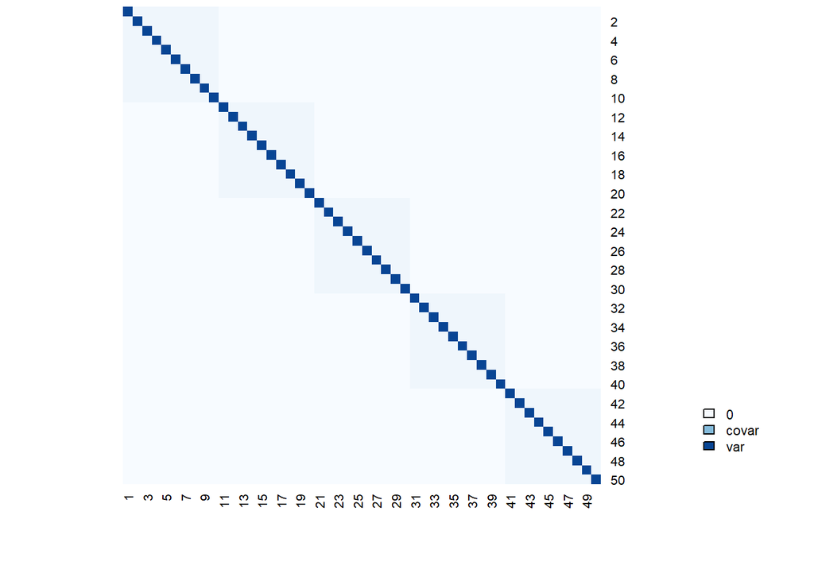

```r
heatmap(m,Rowv=NA,Colv=NA,revC=TRUE,col=colorRampPalette(RColorBrewer::brewer.pal(8, "Blues"))(25))
legend(x="bottomright", legend=c("0", "covar", "var"), bty="n", cex=0.7, fill=colorRampPalette(RColorBrewer::brewer.pal(8, "Blues"))(3))
```

How to interpret this? What are the estimates of the effects of site / sampling values collected from the same plot? We can see the estimates are poor. These are the estimates of the variance for the plot effect, telling us how much *y* varies among sampling units sampled within the same plot - the solvers are not designed to estimate these, but instead to consider them for the fixed effect estimates. Fin.

This data is analyzed via HMSC as follows:

```r
plot.id = as.factor(n.plot)
sample.id = as.factor(1:n)
XData = data.frame(x = x)
Y = as.matrix(y)
studyDesign = data.frame(sample = sample.id, plot = plot.id)
rL = HmscRandomLevel(units = studyDesign$plot)
m2 = Hmsc(Y = Y, XData = XData, XFormula = ~x, studyDesign = studyDesign, ranLevels = list('plot' = rL))

thin = 5
samples = 5000
transient = 1000*thin
m2 = sampleMcmc(m2, thin = thin, samples = samples, transient = transient, nChains = nChains, verbose = verbose, initPar="fixed effects")
```

```
## Computing chain 1
## Hmsc::computeInitialParameter - initializing fixed effects with SSDM estimates
## Chain 1, iteration 2500 of 30000 (transient)
## Chain 1, iteration 5000 of 30000 (transient)
## Chain 1, iteration 7500 of 30000 (sampling)
## Chain 1, iteration 10000 of 30000 (sampling)
## Chain 1, iteration 12500 of 30000 (sampling)
## Chain 1, iteration 15000 of 30000 (sampling)
## Chain 1, iteration 17500 of 30000 (sampling)
## Chain 1, iteration 20000 of 30000 (sampling)
## Chain 1, iteration 22500 of 30000 (sampling)
## Chain 1, iteration 25000 of 30000 (sampling)
## Chain 1, iteration 27500 of 30000 (sampling)
## Chain 1, iteration 30000 of 30000 (sampling)
## Computing chain 2
## Hmsc::computeInitialParameter - initializing fixed effects with SSDM estimates
## Chain 2, iteration 2500 of 30000 (transient)
## Chain 2, iteration 5000 of 30000 (transient)
## Chain 2, iteration 7500 of 30000 (sampling)
## Chain 2, iteration 10000 of 30000 (sampling)
## Chain 2, iteration 12500 of 30000 (sampling)
## Chain 2, iteration 15000 of 30000 (sampling)
## Chain 2, iteration 17500 of 30000 (sampling)
## Chain 2, iteration 20000 of 30000 (sampling)
## Chain 2, iteration 22500 of 30000 (sampling)
## Chain 2, iteration 25000 of 30000 (sampling)
## Chain 2, iteration 27500 of 30000 (sampling)
## Chain 2, iteration 30000 of 30000 (sampling)
```

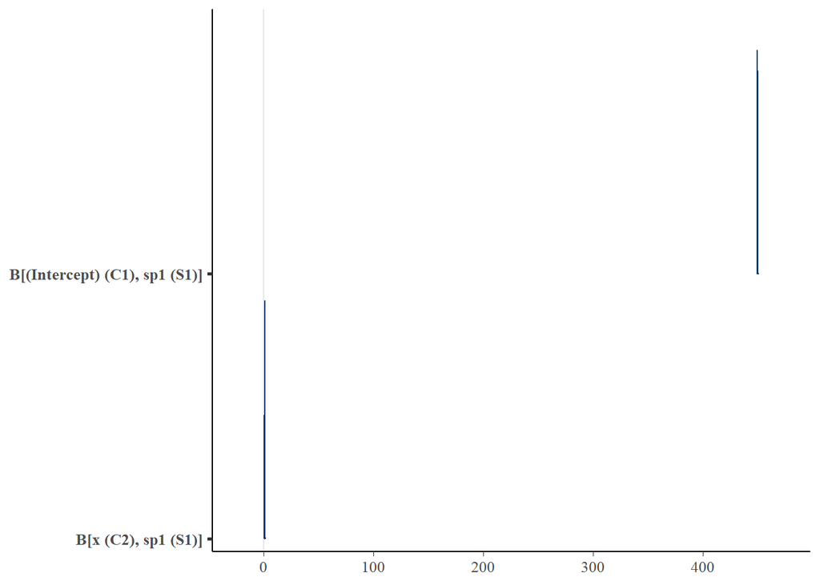

```r
# Interpret results
m2.post = Hmsc::convertToCodaObject(m2)
m2.df <- as.data.frame(rbind(m2.post$Beta[[1]],m2.post$Beta[[2]]))
bayesplot::mcmc_areas(m2.df)
```

```r
summary(m2.post$Beta)
```

```
##
## Iterations = 5005:30000
## Thinning interval = 5
## Number of chains = 2
## Sample size per chain = 5000
##
## 1. Empirical mean and standard deviation for each variable,
##    plus standard error of the mean:
##
##                                  Mean     SD Naive SE Time-series SE
## B[(Intercept) (C1), sp1 (S1)] 449.959 0.1250 0.001250       0.001250
## B[x (C2), sp1 (S1)]             1.101 0.1111 0.001111       0.001111
##
## 2. Quantiles for each variable:
##
##                                   2.5%     25%     50%     75%   97.5%
## B[(Intercept) (C1), sp1 (S1)] 449.7167 449.878 449.959 450.040 450.204
## B[x (C2), sp1 (S1)]             0.8856   1.025   1.101   1.175   1.317
```

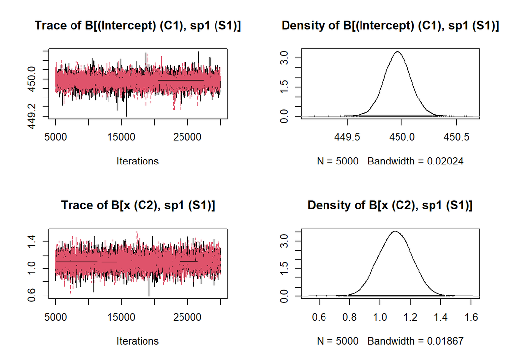

```r
plot(m2.post$Beta)
```

```r
preds = computePredictedValues(m2)
evaluateModelFit(hM=m2, predY=preds)
```

```
## $RMSE
## [1] 0.6908955
##
## $R2
## [1] 0.6890697
```

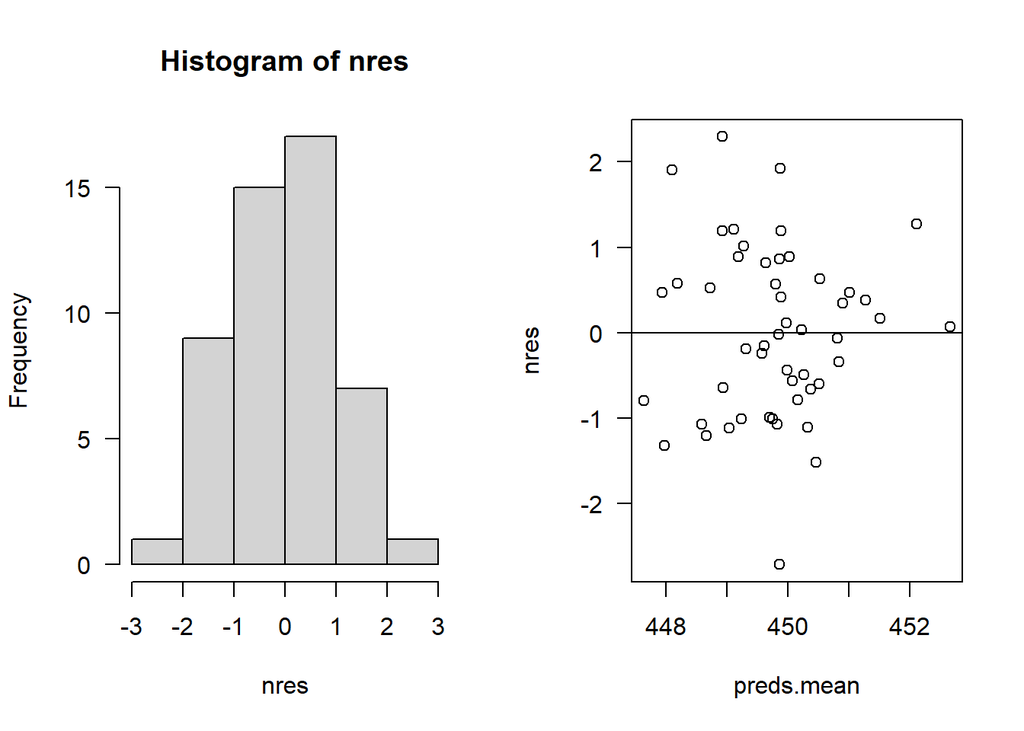

```r
preds.mean = apply(preds, FUN=mean, MARGIN=1)
nres = scale(y-preds.mean)
par(mfrow=c(1,2))
hist(nres, las = 1)
plot(preds.mean,nres, las = 1)
abline(a=0,b=0)
```

We can see that by properly taking the random effects of plot into account, using a mixed model, we can now correctly estimate the $\alpha = \beta_1$ and $\beta = \beta_2$ coefficients.

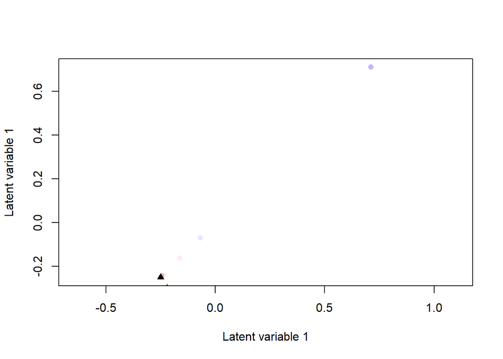

```r
etaPost=getPostEstimate(m2, "Eta")
lambdaPost=getPostEstimate(m2, "Lambda")
biPlot(m2, etaPost = etaPost, lambdaPost = lambdaPost, factors = c(1,1), "x")
```

I will leave the latent variable code for another time, but here are also we end. From Abrego & Ovaskainen, “the model does not have the possibility to estimate the actual random effect for the plot”.